# Multiple and Linear Regressions (extended)

## 6.4 Visualization: Plots that describe the linear regression

#### 3D Plot with Regression Plane

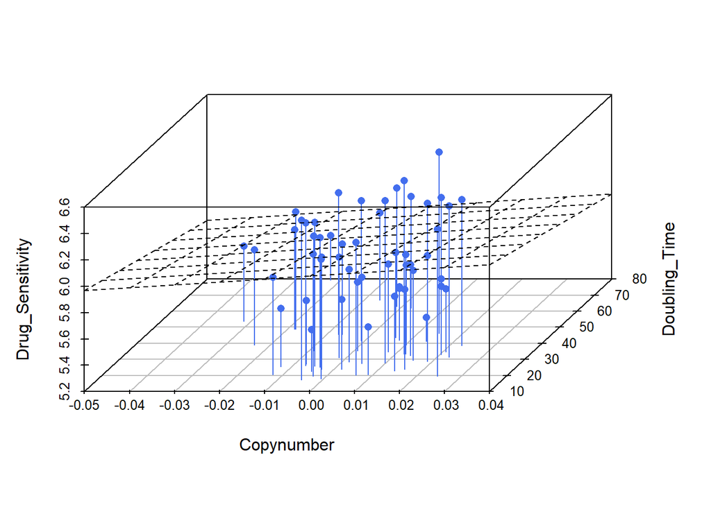

```r
#Creating 3D plot
m_3d <- scatterplot3d(lm_tab_m,
                     type = "h",
                     color = "royalblue2",
                     angle=55,
                     pch = 16)
#Adding regression plane
reg_m_3D <- lm(Drug_Sensitivity ~ Copynumber + Doubling_Time, data = lm_tab_m)
m_3d$plane3d(reg_m_3D)
```

This 3D plot allows us to see the plane created for the multivariate regression and the location of data points in relation to to the plane. Most points are either above the plane or below it. This matches our previous results for the multiple regression, from which we conlcuded there is no relevant relationship between the variables.

### Residual diagnostics: are the various assumptions that underpin linear regression reasonable for our data?

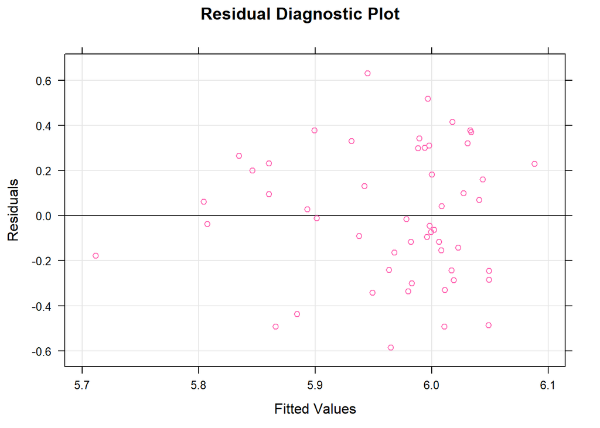

```r
xyplot(resid(reg_m) ~ fitted(reg_m),
       xlab = "Fitted Values",
       ylab = "Residuals",
       main = "Residual Diagnostic Plot",
       col = "hotpink",
       panel = function(x, y, ...)
       {
         panel.grid(h = -1, v = -1)
         panel.abline(h = 0)
         panel.xyplot(x, y, ...)
       }
      )
```

#### Visualization of regression

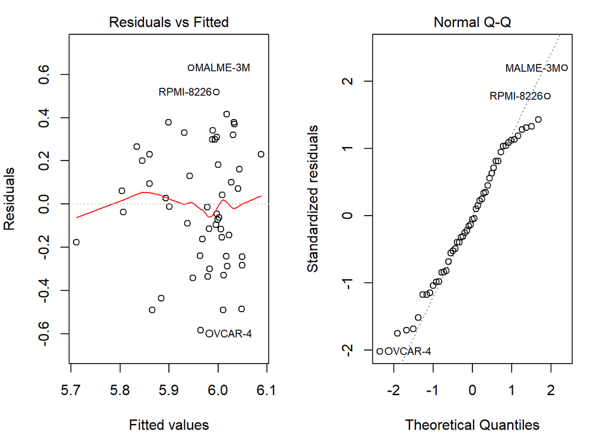

```r
par(mar = c(4, 4, 2, 2), mfrow = c(1, 2))
plot(reg_m, which = c(1, 2))
```

The red line is not straight.

#### Comparing prediction and real values for drug sensitivity

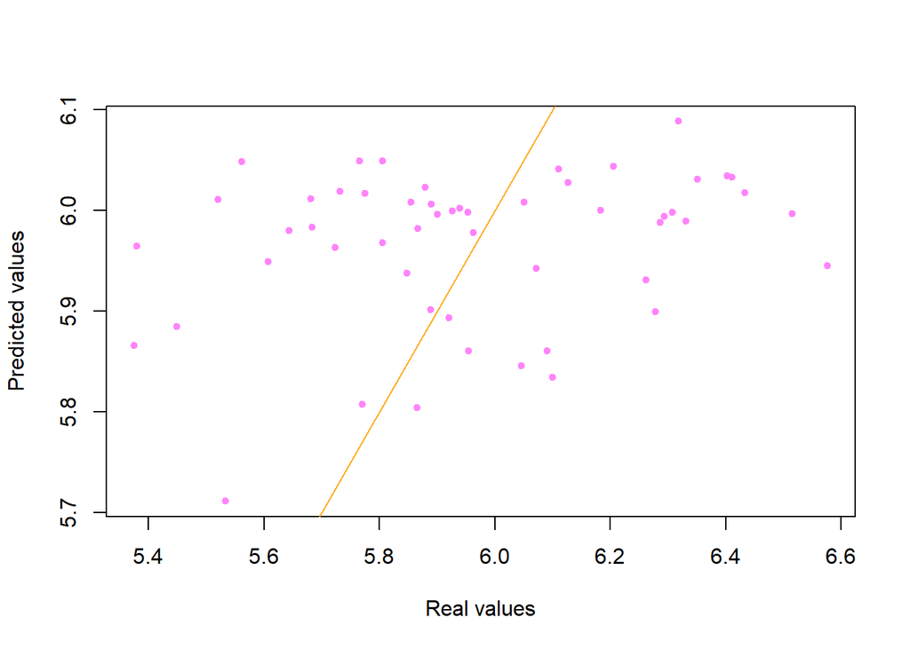

```r
plot(lm_tab_m$Drug_Sensitivity,
     reg_m$fitted.values,
     pch = 20,
     col = "orchid1",
     xlab = "Real values",
     ylab = "Predicted values")
abline(0, 1, col = "orange1")
```

# 7. General Conclusions

The predictions made with the scatter plot, boxplot, density plot and the correlations between the predicted and predicting variable were generally speaking good, as most of these statistical analyses predicted that building a model using linear regression would prove to be not ideal. Once we tested for R-squared and p-value, every regression had extremely low R-quared values, and extremely high p-values. This is of course an undesired result.

Considering the complexity of the process of gene expression, is not entirely surprising that we cannot predict drug sensitivity in a satisfactory way just by relying on copynumber and/or doubling time.

Eventhough no linear relationships were found, we did discover that doubling time is a better tool to predict our data for drug sensitivity than copynumber.

Trying to use a different regression model, would be most likely futile if we take into consideration the results and visualizations of our predictors. Take loess, for example, and think of our scatter plots,a curve does not seem much better fitted to predict our data. Even using other regression models, such as Ridge, that allow more complex curves to be fitted to data, finding a model with both high R-squared and low p-value when we consider our predictors, in particular the scatter plot, seems unlikely.

# **PART 2**

## 8. Using PCA to determine independent variables

## Data

```r
lm_tab_pca = lm_tab_m[,c(3,1,2)]
```

## 8.1 PCA

```r
pca = prcomp(lm_tab_pca[, -1])
summary(pca)
```

```
## Importance of components:
##                          PC1     PC2
## Standard deviation     13.81 0.01241
## Proportion of Variance  1.00 0.00000
## Cumulative Proportion   1.00 1.00000
```

## 8.2 A little correlation exploration

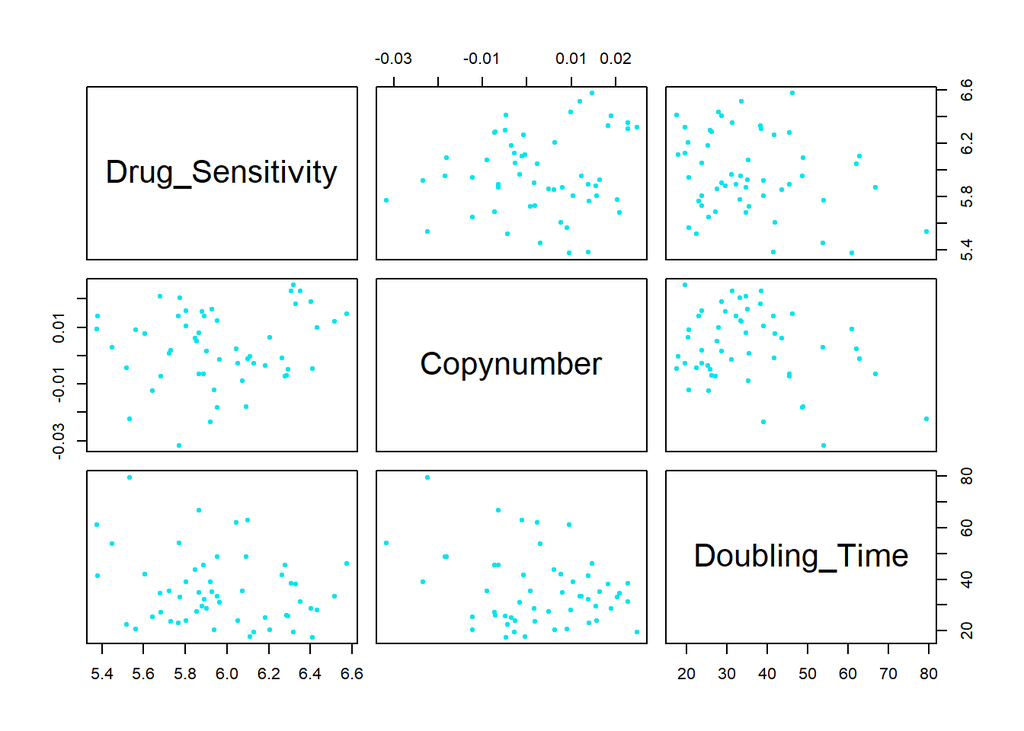

```r
pairs(lm_tab_pca, col = "turquoise2", pch = 20)
```

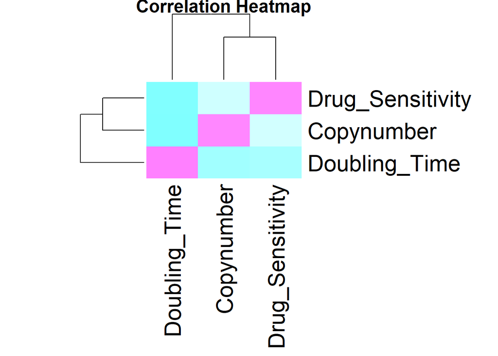

```r
cor_pca = cor(lm_tab_pca)
heatmap(cor_pca,
        col = cm.colors(256),
        margins = c(15, 10),
        main = "Correlation Heatmap")
```

As expected, we observe a higher correlation between doubling time and drug sensitivity than between copynumber and drug sensitivity

### What are exact values for the correlations?

```r
cor(lm_tab_pca)
```

```
##                  Drug_Sensitivity Copynumber Doubling_Time
## Drug_Sensitivity        1.0000000  0.1534729    -0.2360583
## Copynumber              0.1534729  1.0000000    -0.2754990
## Doubling_Time          -0.2360583 -0.2754990     1.0000000
```

Here we confirm that there is indeed a stronger relationship between drug sensitivity and doubling time. Surprisingly, the strongest correlation that we can observe happens to be the one between doubling time and copynumber.

### How significatn are these values?

```r
cor.test(lm_tab_pca$Drug_Sensitivity, lm_tab_pca$Doubling_Time)
```

```
##
##  Pearson's product-moment correlation
##
## data:  lm_tab_pca$Drug_Sensitivity and lm_tab_pca$Doubling_Time
## t = -1.7348, df = 51, p-value = 0.08881
## alternative hypothesis: true correlation is not equal to 0
## 95 percent confidence interval:
##  -0.47598200  0.03656883
## sample estimates:
##        cor
## -0.2360583
```

```r
cor.test(lm_tab_pca$Drug_Sensitivity, lm_tab_pca$Copynumber)
```

```
##
##  Pearson's product-moment correlation
##
## data:  lm_tab_pca$Drug_Sensitivity and lm_tab_pca$Copynumber
## t = 1.1092, df = 51, p-value = 0.2726
## alternative hypothesis: true correlation is not equal to 0
## 95 percent confidence interval:
##  -0.1218767  0.4068879
## sample estimates:
##       cor
## 0.1534729
```

```r
cor.test(lm_tab_pca$Doubling_Time, lm_tab_pca$Copynumber)
```

```
##
##  Pearson's product-moment correlation
##
## data:  lm_tab_pca$Doubling_Time and lm_tab_pca$Copynumber
## t = -2.0467, df = 51, p-value = 0.04586
## alternative hypothesis: true correlation is not equal to 0
## 95 percent confidence interval:
##  -0.507966721 -0.005623974
## sample estimates:
##       cor
## -0.275499
```

Considering these results, the validity of the correlation comes into questions. However, in would still be interesting to explore linear regression with PCA. Therefore, we carry on.

## 8.3 Linear Regression

```r
reg_pca = lm(lm_tab_m$Drug_Sensitivity ~ pca$x)
summary(reg_pca)
```

```
##
## Call:
## lm(formula = lm_tab_m$Drug_Sensitivity ~ pca$x)
##
## Residuals:
##      Min       1Q   Median       3Q      Max
## -0.58469 -0.24027 -0.01499  0.23087  0.63105
##
## Coefficients:
##              Estimate Std. Error t value Pr(>|t|)
## (Intercept)  5.966321   0.040587 147.000   <2e-16 ***
## pca$xPC1     0.005120   0.002967   1.725   0.0906 .
## pca$xPC2    -2.220167   3.301495  -0.672   0.5044
## ---
## Signif. codes:  0 '***' 0.001 '**' 0.01 '*' 0.05 '.' 0.1 ' ' 1
##
## Residual standard error: 0.2955 on 50 degrees of freedom
## Multiple R-squared:  0.06419,    Adjusted R-squared:  0.02675
## F-statistic: 1.715 on 2 and 50 DF,  p-value: 0.1904
```

Multiple R-squared: 0.06419 This indicates that only 6.419% percent of the variation in the data (drug sensitivity) can be explained by the relationship between drug sensitivity, doubling time and copynumber. In other words, there is a 6.419% variance reduction when we take the both the doubling time and the copynumber into account.

# **PART 3**

# 9. REMOVING THE OUTLIERS: Simple linear regression of all genes for drug sensitivity using doubling time

## 9.1 Boxplot: removing the outliers

Boxplot for doubling time

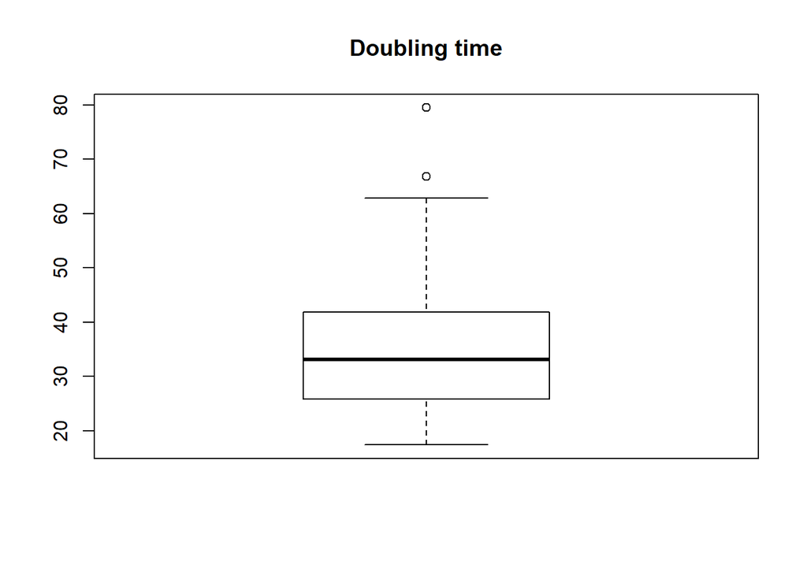

```r
boxplot(lm_tab$Doubling_Time,
        main="Doubling time")
```

What are the values of the outliers?

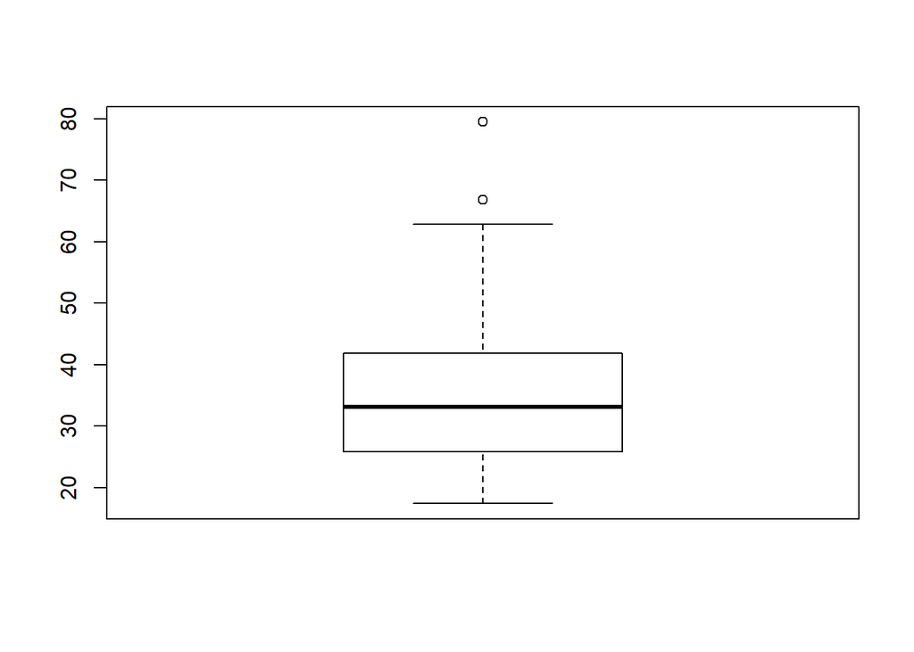

```
## [1] 66.8 79.5
```

```r
boxplot(lm_tab$Doubling_Time)$out
```

Storing the values of the outliers in a vector

```r
outliers_DT <- boxplot(lm_tab$Doubling_Time, plot=FALSE)$out
```

Removing the outliers

```r
lm_tab[which(lm_tab$Doubling_Time %in% outliers_DT),]
```

```
##        Doubling_Time vorinostat
## A498            66.8      5.865
## HOP-92          79.5      5.534
```

We can see that the outliers correspond to those of the cell lines A498 (renal) and HOP-92 (lung).

Creating a new table without the outliers

```r
lm_tab_out <- lm_tab[-which(lm_tab$Doubling_Time %in% outliers_DT),]
```

Checking our results

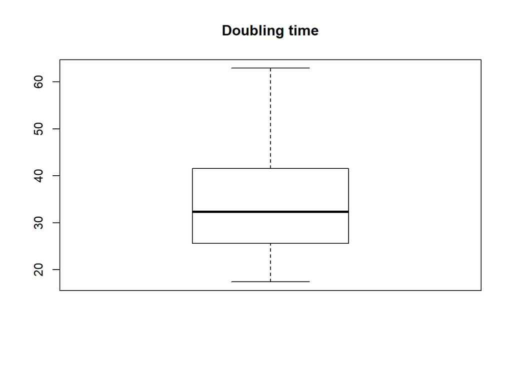

```r
boxplot(lm_tab_out$Doubling_Time,
        main="Doubling time")
```

There are no outliers now

## 9.2 Linear Regression removing the outliers

```r
reg_out <- lm(vorinostat ~ Doubling_Time, data = lm_tab_out)
```

### Details about the linear regression: what we need draw some conclusions

```r
summary(reg_out)
```

```
##
## Call:
## lm(formula = vorinostat ~ Doubling_Time, data = lm_tab_out)
##
## Residuals:
##     Min      1Q  Median      3Q     Max
## -0.5857 -0.2199 -0.0400  0.2514  0.8151
##
## Coefficients:
##                Estimate Std. Error t value Pr(>|t|)
## (Intercept)    6.106988   0.122672  49.783   <2e-16 ***
## Doubling_Time -0.003413   0.003370  -1.013    0.316
## ---
## Signif. codes:  0 '***' 0.001 '**' 0.01 '*' 0.05 '.' 0.1 ' ' 1
##
## Residual standard error: 0.3074 on 57 degrees of freedom
## Multiple R-squared:  0.01767,    Adjusted R-squared:  0.0004385
## F-statistic: 1.025 on 1 and 57 DF,  p-value: 0.3155
```

Multiple R-squared has a value of 0.01767. The Multiple R-squared when the outliers are not removed is 0.04235.

The p-value equals 0.3155. The p-value when the outliers are not removed is 0.1116. The result when the outliers are removed is significantly larger.

We can already observe that this small change, the removal of outliers, has a significant impact on our results.

#### More information about the fit (linear ecuation: y = y-intercept + slope * x) :

```r
confint(reg1)
```

```
##                     2.5 %      97.5 %
## (Intercept)    5.92630793 6.363537831
## Doubling_Time -0.01034593 0.001103791
```

```r
confint(reg_out)
```

```
##                     2.5 %      97.5 %
## (Intercept)    5.86134067 6.352634915
## Doubling_Time -0.01016142 0.003335869
```

Small changes are observed.

## 9.3 Checking the normalization of residuals

### Drug sensitivity vs doubling time: Histogram of the residuals

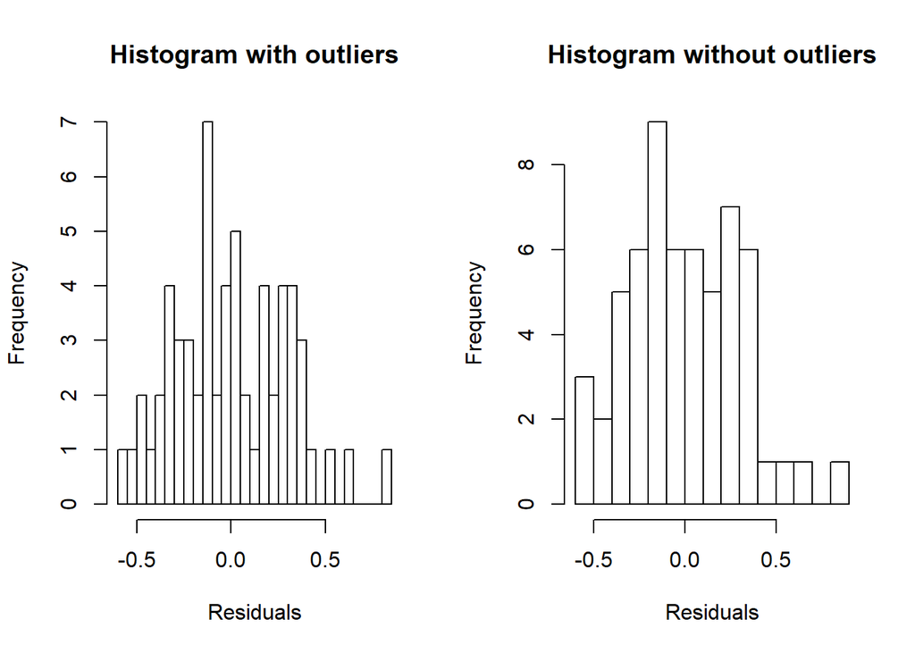

```r
par(mfrow=c(1, 2))
hist(reg1$residuals,
     breaks = 20,
     xlab = "Residuals",
     main = "Histogram with outliers")

hist(reg_out$residuals,
     breaks = 20,
     xlab = "Residuals",
     main = "Histogram without outliers")
```

The data in both histograms does not appear normalized and it is hard to say whether there is a case in which the data looks more normally distributed or not.

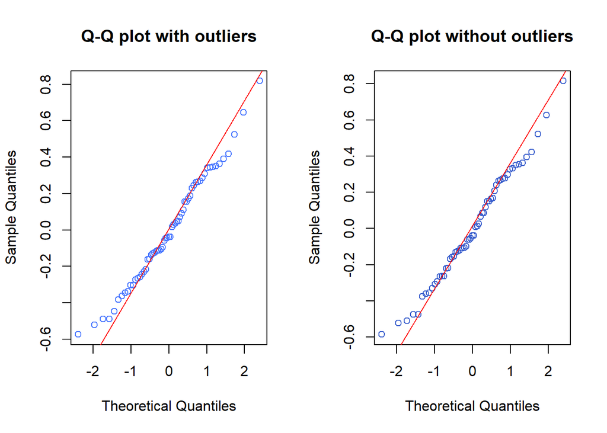

```r
par(mfrow=c(1, 2))

qqnorm(reg1$residuals,
       main = "Q-Q plot with outliers",
       col = "royalblue1")
qqline(reg1$residuals,
       col = "red")

qqnorm(reg_out$residuals,
       main = "Q-Q plot without outliers",
       col = "royalblue3")
qqline(reg_out$residuals,
       col = "red")
```

Small changes can be observed between values 1 and 2.

## 9.4 Visualization: Plots that describe the linear regression

### Residual diagnostics: are the various assumptions that underpin linear regression reasonable for our data?

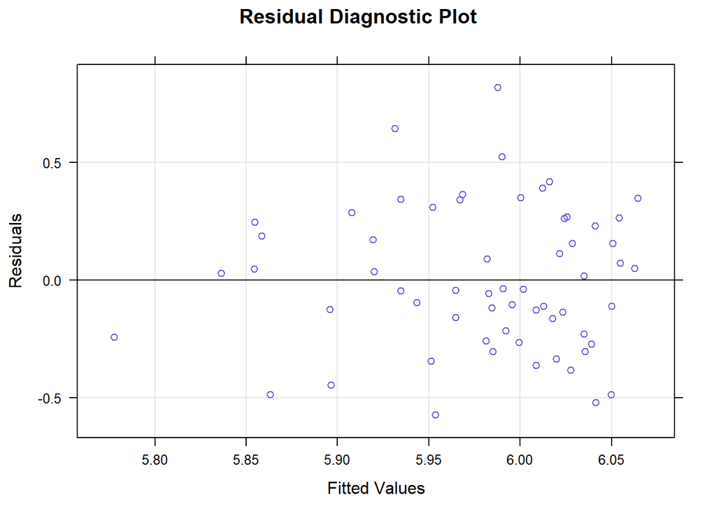

```r
par(mfrow=c(1, 2))

xyplot(resid(reg1) ~ fitted(reg1),
       xlab = "Fitted Values",
       ylab = "Residuals",
       main = "Residual Diagnostic Plot",
       col = "slateblue3",
       panel = function(x, y, ...)
       {
         panel.grid(h = -1, v = -1)
         panel.abline(h = 0)
         panel.xyplot(x, y, ...)
       }
      )
```

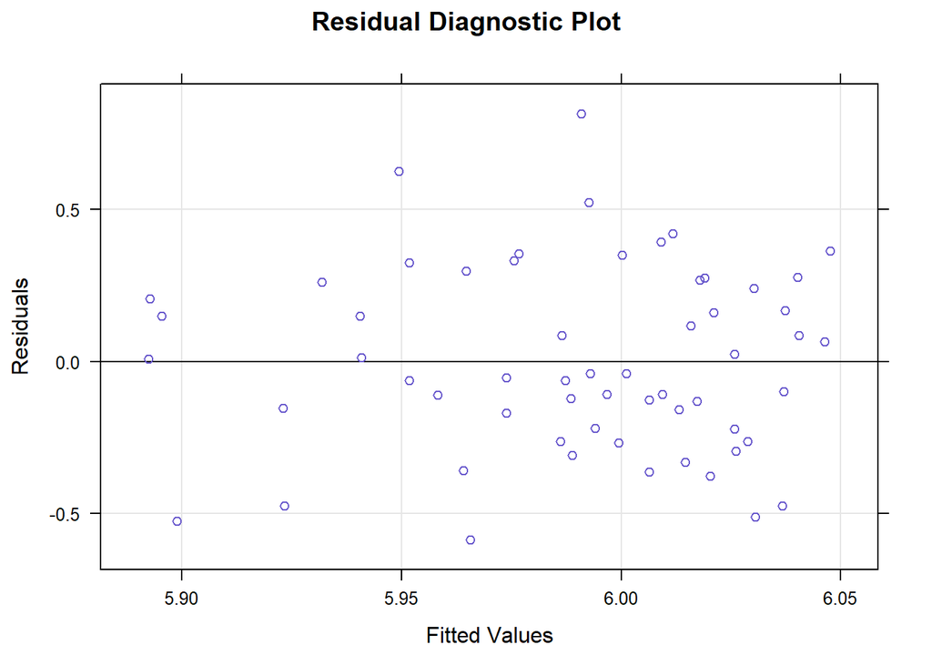

```r
xyplot(resid(reg_out) ~ fitted(reg_out),
       xlab = "Fitted Values",
       ylab = "Residuals",
       main = "Residual Diagnostic Plot",
       col = "slateblue3",
       panel = function(x, y, ...)
       {
         panel.grid(h = -1, v = -1)
         panel.abline(h = 0)
         panel.xyplot(x, y, ...)
       }
      )
```

The data for reg_out appears to be more spread.

#### Visualization of regression

Plots with outliers are on top and those without are on the bottom.

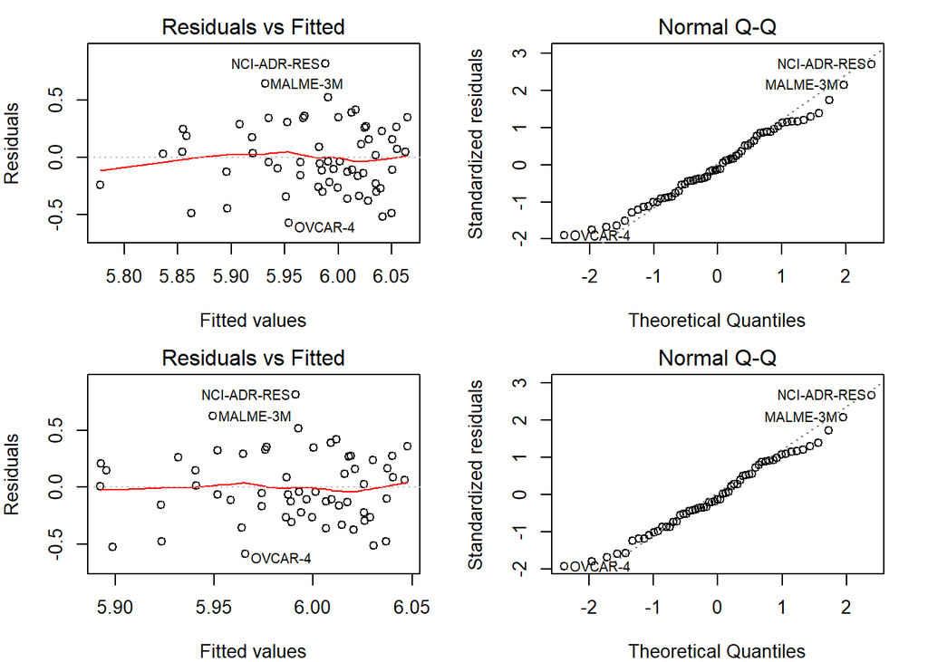

```r
par(mar = c(4, 4, 2, 2), mfrow = c(2, 2))
plot(reg1, which = c(1, 2))
plot(reg_out, which = c(1, 2))
```

The line drawn accross the scatter plot changes when we remove the outliers.

#### Comparing prediction and real values for drug sensitivity

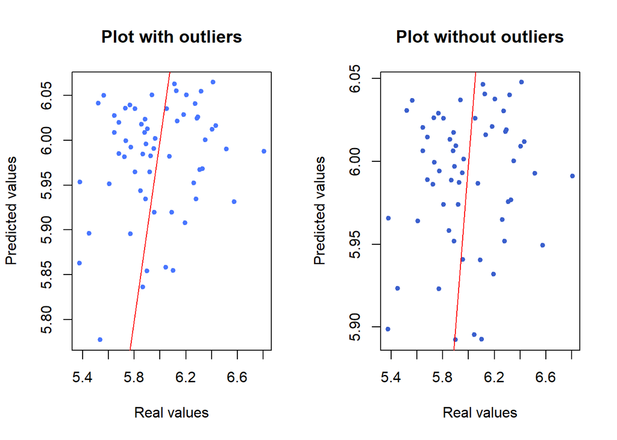

```r
par(mfrow=c(1, 2))

plot(lm_tab$vorinostat,
     reg1$fitted.values,
     pch = 20,
     col = "royalblue1",
     xlab = "Real values",
     ylab = "Predicted values",
     main = "Plot with outliers")
abline(0, 1, col = "red")

plot(lm_tab_out$vorinostat,
     reg_out$fitted.values,
     pch = 20,
     col = "royalblue3",
     xlab = "Real values",
     ylab = "Predicted values",
     main = "Plot without outliers")
abline(0, 1, col = "red")
```

## 9.5 General Conclusions

There are small differences in the plots when the outliers are removed. The relationship between both variables gets more uncertain when the outliers are removed. As the R-Squared value decreases and p-value increases, it is not safe to say whether removing the outliers is better or not. The resukts of this small exploratory analysis do not allow us to know which option will render more truthfull results. The conclusion we can draw is that outliers have a powerful effect on the end results of a statistical analysis and that they should be considered when making any kind of analysis.

# **PART 4**

# 10. Comparing the results for the linear regression of drug sensitivity vs copynumber using only the biomarkers wvs using all genes.

While the value of R-squared when using the biomarkers is of 0.004101 and the p-value is equal to 0.6487, when all genes are used instead R-squared has a value of 0.02355 and the p-value is 0.2726.

R-squared is significantly greater when using all genes and the p-value is significantly smaller. Therefore better results are expected when using all genes.

# 11. Linear Regression with specific genes: Drug Sensitivity vs Copynumber (#anchor37)

## 11.1. Linear Regression with top 3 biomarkers (#anchor38)

Here we use the first 3 rows of the table BM_Copynumber, which contains the copynumber values for the top 100 biomarkers.Using the table FC_both_sorted, which contains the biomarkers in decreasing order of importance. The genes we analyse in this part are DHRS2, ABAT and SERPINI1.

### Linear Regression for DHRS2: Preparing the data

First we take the copynumber values of this gene only.

```r
DHRS2 <- BM_copynumber[-c(2:90),]
```

#### Data frames

```r
DHRS2 = as.data.frame(t(DHRS2))

DS = as.data.frame(drug_sensitivity)
```

#### Table with drug sensitivity and relevant gene per cell line

```r
lm_tab_DHRS2 = transform(merge(DHRS2,DS,by=0,all=TRUE), row.names=Row.names, Row.names=NULL)

lm_tab_DHRS2 <- na.omit(lm_tab_DHRS2)
```

#### Linear Regression for DHRS2

```r
reg_DHRS2 <- lm(vorinostat ~ DHRS2, data = lm_tab_DHRS2)
```

#### Details about the linear regression: what we need draw some conclusions

```r
summary(reg_DHRS2)
```

```
##
## Call:
## lm(formula = vorinostat ~ DHRS2, data = lm_tab_DHRS2)
##
## Residuals:
##      Min       1Q   Median       3Q      Max
## -0.59157 -0.19627 -0.04015  0.23865  0.60937
##
## Coefficients:
##              Estimate Std. Error t value Pr(>|t|)
## (Intercept) 5.9664345  0.0438848 135.957   <2e-16 ***
## DHRS2       0.0009801  0.1219281   0.008    0.994
## ---
## Signif. codes:  0 '***' 0.001 '**' 0.01 '*' 0.05 '.' 0.1 ' ' 1
##
## Residual standard error: 0.3024 on 51 degrees of freedom
## Multiple R-squared:  1.267e-06,  Adjusted R-squared:  -0.01961
## F-statistic: 6.462e-05 on 1 and 51 DF,  p-value: 0.9936
```

***Multiple R-squared**: 1.267e-06

***p-value**: 0.9936

### Linear Regression for ABAT: Preparing the data

First we take the copynumber values of this gene only.

```r
ABAT <- Copynumber["ABAT",]
```

#### Data frames

```r
ABAT = as.data.frame(t(ABAT))

DS = as.data.frame(drug_sensitivity)
```

#### Table with drug sensitivity and relevant gene copynumber per cell line

```r
lm_tab_ABAT = transform(merge(ABAT,DS,by=0,all=TRUE), row.names=Row.names, Row.names=NULL)

lm_tab_ABAT <- na.omit(lm_tab_ABAT)
```

#### Linear Regression for ABAT

```r
reg_ABAT <- lm(vorinostat ~ ABAT, data = lm_tab_ABAT)
```

#### Details about the linear regression: what we need draw some conclusions

```r
summary(reg_ABAT)
```

```
##
## Call:
## lm(formula = vorinostat ~ ABAT, data = lm_tab_ABAT)
##
## Residuals:
##      Min       1Q   Median       3Q      Max
## -0.63971 -0.18959 -0.02334  0.23863  0.78683
##
## Coefficients:
##             Estimate Std. Error t value Pr(>|t|)
## (Intercept)  5.98768    0.04232 141.475   <2e-16 ***
## ABAT         0.22192    0.13060   1.699   0.0954 .
## ---
## Signif. codes:  0 '***' 0.001 '**' 0.01 '*' 0.05 '.' 0.1 ' ' 1
##
## Residual standard error: 0.2942 on 51 degrees of freedom
## Multiple R-squared:  0.05358,    Adjusted R-squared:  0.03503
## F-statistic: 2.887 on 1 and 51 DF,  p-value: 0.09537
```

***Multiple R-squared**: 0.05358

***p-value**: 0.09537

### Linear Regression for SERPINI1: Preparing the data

First we take the copynumber values of this gene only.

```r
SERPINI1 <- Copynumber["SERPINI1",]
```

#### Data frames

```r
SERPINI1 = as.data.frame(t(SERPINI1))

DS = as.data.frame(drug_sensitivity)
```

#### Table with drug sensitivity and relevant gene copynumber per cell line

```r
lm_tab_SERPINI1 = transform(merge(SERPINI1,DS,by=0,all=TRUE), row.names=Row.names, Row.names=NULL)

lm_tab_SERPINI1 <- na.omit(lm_tab_SERPINI1)
```

#### Linear Regression for SERPINI1

```r
reg_SERPINI1 <- lm(vorinostat ~ SERPINI1, data = lm_tab_SERPINI1)
```

#### Details about the linear regression: what we need draw some conclusions

```r
summary(reg_SERPINI1)
```

```
##
## Call:
## lm(formula = vorinostat ~ SERPINI1, data = lm_tab_SERPINI1)
##
## Residuals:
##      Min       1Q   Median       3Q      Max
## -0.62524 -0.20195 -0.03755  0.21885  0.61737
##
## Coefficients:
##             Estimate Std. Error t value Pr(>|t|)
## (Intercept)  5.96883    0.04161 143.440   <2e-16 ***
## SERPINI1    -0.03228    0.05421  -0.595    0.554
## ---
## Signif. codes:  0 '***' 0.001 '**' 0.01 '*' 0.05 '.' 0.1 ' ' 1
##
## Residual standard error: 0.3014 on 51 degrees of freedom
## Multiple R-squared:  0.006903,   Adjusted R-squared:  -0.01257
## F-statistic: 0.3545 on 1 and 51 DF,  p-value: 0.5542
```

***Multiple R-squared**: 0.006903

***p-value**: 0.5542

## 11.2. Linear Regression with 3 non-biomarker genes (#anchor39)

Here we use the functions to sort biomarkers according to their mean value to check which genes are the least relevant ones in terms of change of expression after treatment with vorinostat.

### Linear Regression for CABP2: Preparing the data

First we take the copynumber values of this gene only.

```r
CABP2 <- Copynumber["CABP2",]
```

#### Data frames

```r
CABP2 = as.data.frame(t(CABP2))

DS = as.data.frame(drug_sensitivity)
```

#### Table with drug sensitivity and relevant gene copynumber per cell line

```r
lm_tab_CABP2 = transform(merge(CABP2,DS,by=0,all=TRUE), row.names=Row.names, Row.names=NULL)

lm_tab_CABP2 <- na.omit(lm_tab_CABP2)
```

#### Linear Regression for CABP2

```r
reg_CABP2 <- lm(vorinostat ~ CABP2, data = lm_tab_CABP2)
```

#### Details about the linear regression: what we need draw some conclusions

```r
summary(reg_CABP2)
```

```
##
## Call:
## lm(formula = vorinostat ~ CABP2, data = lm_tab_CABP2)
##
## Residuals:
##      Min       1Q   Median       3Q      Max
## -0.59148 -0.19568 -0.03463  0.23692  0.61507
##
## Coefficients:
##             Estimate Std. Error t value Pr(>|t|)
## (Intercept) 5.965857   0.042171 141.468   <2e-16 ***
## CABP2       0.006756   0.105756   0.064    0.949
## ---
## Signif. codes:  0 '***' 0.001 '**' 0.01 '*' 0.05 '.' 0.1 ' ' 1
##
## Residual standard error: 0.3024 on 51 degrees of freedom
## Multiple R-squared:  8.001e-05,  Adjusted R-squared:  -0.01953
## F-statistic: 0.004081 on 1 and 51 DF,  p-value: 0.9493
```

***Multiple R-squared**: 8.001e-05

***p-value**: 0.9493

### Linear Regression for UPK2: Preparing the data

First we take the copynumber values of this gene only.

```r
UPK2 <- Copynumber["UPK2",]
```

#### Data frames

```r
UPK2 = as.data.frame(t(UPK2))

DS = as.data.frame(drug_sensitivity)
```

#### Table with drug sensitivity and relevant gene copynumber per cell line

```r
lm_tab_UPK2 = transform(merge(UPK2,DS,by=0,all=TRUE), row.names=Row.names, Row.names=NULL)

lm_tab_UPK2 <- na.omit(lm_tab_UPK2)
```

#### Linear Regression for UPK2

```r
reg_UPK2 <- lm(vorinostat ~ UPK2, data = lm_tab_UPK2)
```

#### Details about the linear regression: what we need draw some conclusions

```r
summary(reg_UPK2)
```

```
##
## Call:
## lm(formula = vorinostat ~ UPK2, data = lm_tab_UPK2)
##
## Residuals:
##      Min       1Q   Median       3Q      Max
## -0.58742 -0.19697 -0.05403  0.24721  0.58851
##
## Coefficients:
##             Estimate Std. Error t value Pr(>|t|)
## (Intercept)  5.96565    0.04156 143.553   <2e-16 ***
## UPK2        -0.02743    0.08684  -0.316    0.753
## ---
## Signif. codes:  0 '***' 0.001 '**' 0.01 '*' 0.05 '.' 0.1 ' ' 1
##
## Residual standard error: 0.3021 on 51 degrees of freedom
## Multiple R-squared:  0.001952,   Adjusted R-squared:  -0.01762
## F-statistic: 0.09973 on 1 and 51 DF,  p-value: 0.7534
```

***Multiple R-squared**: 0.001952

***p-value**: 0.7534

### Linear Regression for CLPS: Preparing the data

First we take the copynumber values of this gene only.

```r
CLPS <- Copynumber["CLPS",]
```

#### Data frames

```r
CLPS = as.data.frame(t(CLPS))

DS = as.data.frame(drug_sensitivity)
```

#### Table with drug sensitivity and relevant gene copynumber per cell line

```r
lm_tab_CLPS = transform(merge(CLPS,DS,by=0,all=TRUE), row.names=Row.names, Row.names=NULL)

lm_tab_CLPS <- na.omit(lm_tab_CLPS)
```

#### Linear Regression for CLPS

```r
reg_CLPS <- lm(vorinostat ~ CLPS, data = lm_tab_CLPS)
```

#### Details about the linear regression: what we need draw some conclusions

```r
summary(reg_CLPS)
```

```
##
## Call:
## lm(formula = vorinostat ~ CLPS, data = lm_tab_CLPS)
##
## Residuals:
##      Min       1Q   Median       3Q      Max
## -0.59090 -0.19653 -0.03422  0.24837  0.59289
##
## Coefficients:
##             Estimate Std. Error t value Pr(>|t|)
## (Intercept)  5.96195    0.04198 142.029   <2e-16 ***
## CLPS         0.07312    0.11741   0.623    0.536
## ---
## Signif. codes:  0 '***' 0.001 '**' 0.01 '*' 0.05 '.' 0.1 ' ' 1
##
## Residual standard error: 0.3013 on 51 degrees of freedom
## Multiple R-squared:  0.007549,   Adjusted R-squared:  -0.01191
## F-statistic: 0.3879 on 1 and 51 DF,  p-value: 0.5362
```

***Multiple R-squared**: 0.007549

***p-value**: 0.5362

In this part of this analysis, we find find the genes with the highest and lowest values for copynumber. To achieve this, we find the mean of the absolute values and then sort the results in decresing order.

```r
Copynumber_av= abs(Copynumber)
Copynumber_mean= rowMeans(Copynumber_av)

Copynumber_sav <- sort(Copynumber_mean, decreasing = TRUE)
Copynumber_sav <- as.matrix(Copynumber_sav)
```

#### Top 10

```r
CN_top10 = Copynumber_sav[1:10,]
CN_top10
```

```
##      DAZ2       UTY      DAZ1     DDX3Y    TTTY20  FAM197Y5 FAM197Y2P
##  3.645445  3.172730  2.936079  2.818717  2.681708  2.671509  2.671509
##     TSPY1     TSPY3     TSPY4
##  2.671509  2.671509  2.671509
```

```r
CN_lowest10 = Copynumber_sav[23306:23316,]
CN_lowest10
```

```
##     MIR545     MIR421      ABCB7   KIAA2022       RLIM       XIST
## 0.09233774 0.09233774 0.09197547 0.09197547 0.09197547 0.09192264
##    CXorf26     MAGEE1    ZDHHC15     MAGEE2     TTC3P1
## 0.09169434 0.09169434 0.09134340 0.09126415 0.09126415
```

### 11.3.1. Top 3 mean values for Copynumber (#anchor41)

### Linear Regression for DAZ2: Preparing the data

First we take the copynumber values of this gene only.

```r
DAZ2 <- Copynumber["DAZ2",]
```

#### Data frames

```r
DAZ2 = as.data.frame(t(DAZ2))

DS = as.data.frame(drug_sensitivity)
```

#### Table with drug sensitivity and relevant gene copynumber per cell line

```r
lm_tab_DAZ2 = transform(merge(DAZ2,DS,by=0,all=TRUE), row.names=Row.names, Row.names=NULL)

lm_tab_DAZ2 <- na.omit(lm_tab_DAZ2)
```

#### Linear Regression for DAZ2

```r
reg_DAZ2 <- lm(vorinostat ~ DAZ2, data = lm_tab_DAZ2)
```

#### Details about the linear regression: what we need draw some conclusions

```r
summary(reg_DAZ2)
```

```
##
## Call:
## lm(formula = vorinostat ~ DAZ2, data = lm_tab_DAZ2)
##
## Residuals:
##      Min       1Q   Median       3Q      Max
## -0.59404 -0.18668 -0.03927  0.24021  0.62242
##
## Coefficients:
##              Estimate Std. Error t value Pr(>|t|)
## (Intercept)  5.948505   0.092125  64.570   <2e-16 ***
## DAZ2        -0.004887   0.022559  -0.217    0.829
## ---
## Signif. codes:  0 '***' 0.001 '**' 0.01 '*' 0.05 '.' 0.1 ' ' 1
##
## Residual standard error: 0.3023 on 51 degrees of freedom
## Multiple R-squared:  0.0009194,  Adjusted R-squared:  -0.01867
## F-statistic: 0.04693 on 1 and 51 DF,  p-value: 0.8294
```

***Multiple R-squared**: 0.0009194

***p-value**: 0.8294

### Linear Regression for UTY: Preparing the data

First we take the copynumber values of this gene only.

```r
UTY <- Copynumber["UTY",]
```

#### Data frames

```r
UTY = as.data.frame(t(UTY))

DS = as.data.frame(drug_sensitivity)
```

#### Table with drug sensitivity and relevant gene copynumber per cell line

```r
lm_tab_UTY = transform(merge(UTY,DS,by=0,all=TRUE), row.names=Row.names, Row.names=NULL)

lm_tab_UTY <- na.omit(lm_tab_UTY)
```

#### Linear Regression for UTY

```r
reg_UTY <- lm(vorinostat ~ UTY, data = lm_tab_UTY)
```

#### Details about the linear regression: what we need draw some conclusions

```r
summary(reg_UTY)
```

```
##
## Call:
## lm(formula = vorinostat ~ UTY, data = lm_tab_UTY)
##
## Residuals:
##      Min       1Q   Median       3Q      Max
## -0.58725 -0.18883 -0.04519  0.24060  0.61991
##
## Coefficients:
##              Estimate Std. Error t value Pr(>|t|)
## (Intercept)  5.951263   0.077279  77.010   <2e-16 ***
## UTY         -0.004746   0.020543  -0.231    0.818
## ---
## Signif. codes:  0 '***' 0.001 '**' 0.01 '*' 0.05 '.' 0.1 ' ' 1
##
## Residual standard error: 0.3023 on 51 degrees of freedom
## Multiple R-squared:  0.001045,   Adjusted R-squared:  -0.01854
## F-statistic: 0.05337 on 1 and 51 DF,  p-value: 0.8182
```

***Multiple R-squared**: 0.001045

***p-value**: 0.8182

### Linear Regression for DAZ1: Preparing the data

First we take the copynumber values of this gene only.

```r
DAZ1 <- Copynumber["DAZ1",]
```

#### Data frames

```r
DAZ1 = as.data.frame(t(DAZ1))

DS = as.data.frame(drug_sensitivity)
```

#### Table with drug sensitivity and relevant gene copynumber per cell line

```r
lm_tab_DAZ1 = transform(merge(DAZ1,DS,by=0,all=TRUE), row.names=Row.names, Row.names=NULL)

lm_tab_DAZ1 <- na.omit(lm_tab_DAZ1)
```

#### Linear Regression for DAZ1

```r
reg_DAZ1 <- lm(vorinostat ~ DAZ1, data = lm_tab_DAZ1)
```

#### Details about the linear regression: what we need draw some conclusions

```r
summary(reg_DAZ1)
```

```
##
## Call:
## lm(formula = vorinostat ~ DAZ1, data = lm_tab_DAZ1)
##
## Residuals:
##      Min       1Q   Median       3Q      Max
## -0.59976 -0.17414 -0.04757  0.23286  0.63758
##
## Coefficients:
##             Estimate Std. Error t value Pr(>|t|)
## (Intercept)  5.92317    0.10445   56.71   <2e-16 ***
## DAZ1        -0.01470    0.03265   -0.45    0.655
## ---
## Signif. codes:  0 '***' 0.001 '**' 0.01 '*' 0.05 '.' 0.1 ' ' 1
##
## Residual standard error: 0.3018 on 51 degrees of freedom
## Multiple R-squared:  0.003956,   Adjusted R-squared:  -0.01557
## F-statistic: 0.2026 on 1 and 51 DF,  p-value: 0.6546
```

***Multiple R-squared**: 0.003956

***p-value**: 0.6546

### Linear Regression for RBM18: Preparing the data

First we take the copynumber values of this gene only.

```r
RBM18 <- Copynumber["RBM18",]
```

#### Data frames

```r
RBM18 = as.data.frame(t(RBM18))

DS = as.data.frame(drug_sensitivity)
```

#### Table with drug sensitivity and relevant gene copynumber per cell line

```r
lm_tab_RBM18 = transform(merge(RBM18,DS,by=0,all=TRUE), row.names=Row.names, Row.names=NULL)

lm_tab_RBM18 <- na.omit(lm_tab_RBM18)
```

#### Linear Regression for RBM18

```r
reg_RBM18 <- lm(vorinostat ~ RBM18, data = lm_tab_RBM18)
```

#### Details about the linear regression: what we need draw some conclusions

```r
summary(reg_RBM18)
```

```
##
## Call:
## lm(formula = vorinostat ~ RBM18, data = lm_tab_RBM18)
##
## Residuals:
##      Min       1Q   Median       3Q      Max
## -0.59136 -0.19646 -0.04028  0.23875  0.60989
##
## Coefficients:
##              Estimate Std. Error t value Pr(>|t|)
## (Intercept) 5.9663207  0.0415426 143.619   <2e-16 ***
## RBM18       0.0009011  0.1566395   0.006    0.995
## ---
## Signif. codes:  0 '***' 0.001 '**' 0.01 '*' 0.05 '.' 0.1 ' ' 1
##
## Residual standard error: 0.3024 on 51 degrees of freedom
## Multiple R-squared:  6.488e-07,  Adjusted R-squared:  -0.01961
## F-statistic: 3.309e-05 on 1 and 51 DF,  p-value: 0.9954
```

***Multiple R-squared**: 6.488e-07

- **p-value**: 0.9954

### Linear Regression for MIR3974: Preparing the data

First we take the copynumber values of this gene only.

```r
MIR3974 <- Copynumber["MIR3974",]
```

#### Data frames

```r
MIR3974 = as.data.frame(t(MIR3974))

DS = as.data.frame(drug_sensitivity)
```

#### Table with drug sensitivity and relevant gene copynumber per cell line

```r
lm_tab_MIR3974 = transform(merge(MIR3974,DS,by=0,all=TRUE), row.names=Row.names, Row.names=NULL)

lm_tab_MIR3974 <- na.omit(lm_tab_MIR3974)
```

#### Linear Regression for MIR3974

```r
reg_MIR3974 <- lm(vorinostat ~ MIR3974, data = lm_tab_MIR3974)
```

#### Details about the linear regression: what we need draw some conclusions

```r
summary(reg_MIR3974)
```

```
##
## Call:
## lm(formula = vorinostat ~ MIR3974, data = lm_tab_MIR3974)
##
## Residuals:
##      Min       1Q   Median       3Q      Max
## -0.60045 -0.22259 -0.05379  0.21629  0.59201
##
## Coefficients:
##             Estimate Std. Error t value Pr(>|t|)
## (Intercept)  5.96631    0.04123 144.696   <2e-16 ***
## MIR3974      0.10808    0.12337   0.876    0.385
## ---
## Signif. codes:  0 '***' 0.001 '**' 0.01 '*' 0.05 '.' 0.1 ' ' 1
##
## Residual standard error: 0.3002 on 51 degrees of freedom
## Multiple R-squared:  0.01483,    Adjusted R-squared:  -0.004492
## F-statistic: 0.7675 on 1 and 51 DF,  p-value: 0.3851
```

- **Multiple R-squared**: 0.01483
- **p-value**: 0.3851

### Linear Regression for SKP1P2: Preparing the data

First we take the copynumber values of this gene only.

```r
SKP1P2 <- Copynumber["SKP1P2",]
```

#### Data frames

```r
SKP1P2 = as.data.frame(t(SKP1P2))

DS = as.data.frame(drug_sensitivity)
```

#### Table with drug sensitivity and relevant gene copynumber per cell line

```r
lm_tab_SKP1P2 = transform(merge(SKP1P2,DS,by=0,all=TRUE), row.names=Row.names, Row.names=NULL)

lm_tab_SKP1P2 <- na.omit(lm_tab_SKP1P2)
```

#### Linear Regression for SKP1P2

```r
reg_SKP1P2 <- lm(vorinostat ~ SKP1P2, data = lm_tab_SKP1P2)
```

#### Details about the linear regression: what we need draw some conclusions

```r
summary(reg_SKP1P2)
```

```
##
## Call:
## lm(formula = vorinostat ~ SKP1P2, data = lm_tab_SKP1P2)
##
## Residuals:
##     Min      1Q  Median      3Q     Max
## -0.6005 -0.2226 -0.0538  0.2163  0.5920
##
## Coefficients:
##             Estimate Std. Error t value Pr(>|t|)
## (Intercept)  5.96632    0.04123 144.696   <2e-16 ***
## SKP1P2       0.10814    0.12344   0.876    0.385
## ---
## Signif. codes:  0 '***' 0.001 '**' 0.01 '*' 0.05 '.' 0.1 ' ' 1
##
## Residual standard error: 0.3002 on 51 degrees of freedom
## Multiple R-squared:  0.01483,    Adjusted R-squared:  -0.00449
## F-statistic: 0.7676 on 1 and 51 DF,  p-value: 0.3851
```

- **Multiple R-squared**: 0.01483
- **p-value**: 0.3851

# 12. Table with summary (#anchor43)

[output not shown]